# Analysis of Turkey’s Trade with Selected Countries

Dec 26<sup>th</sup>, 2018

## Team Members & Abstract

- [Busra Koc](https://mef-bda503.github.io/pj18-busraakoc/)
- [Emre Kemerci](https://mef-bda503.github.io/pj18-EmreKemerci/)
- [Muharrem Cakir](https://mef-bda503.github.io/pj18-muharremcakir81/)
- [Omer Bayir](https://mef-bda503.github.io/pj18-omerbayir/)
- [Salih Ucar](https://mef-bda503.github.io/pj18-ucarsal/)

In this term project, trade statistics data of Turkey against the G7 countries and 3 more countries (Russia, India, China) is analysed. The aim of the project is to analyze Turkey’s export and import characteristics by product groups considering the trade value and quantities.

The purpose of the analysis is to understand the Turkey’s trade Statistics for two way and with ten important countries.

Describe Turkey’s the trade deficit with the country,year and product dimensions. Try to clear which factors effects deficit in trade, and is there relation deficit and other financials.

A clear understanding of the data to see if we can locate useful insights about which products and countries will remain the deficit and wich of them will be strategic for Turkey

## Explanation of Raw Data and Data Preparation

- 10 countries’ trade data against Turkey are taken from [Trademap.org](https://trademap.org/Index.aspx) as 4 seperate excel tables, Export&Import Quantity and Export&Import Values
- Quantity and Value tables joined following the binding operation of 10 countries tables. Besides, 2 digit product code table have been joined.
- Same type of variables collated to one and “years”" melted to prevent repetition of quantity and value variables.

```
## Observations: 61,100
## Variables: 9
## $ Country       <chr> "Canada", "Canada", "Canada", "Canada", "Canada"...
## $ PcodeTwo      <chr> "72", "69", "25", "72", "68", "73", "73", "26", ...
## $ X__2          <chr> "Iron and steel", "Ceramic products", "Salt; sul...
## $ Product_Code  <chr> "7214", "6907", "2523", "7208", "6802", "7306", ...
## $ Product_Label <chr> "Bars and rods, of iron or non-alloy steel, not ...
## $ Unit          <chr> "Tons", "Tons", "Tons", "Tons", "Tons", "Tons", ...
## $ Quantity      <dbl> 131711, 1795, 22000, 220, 46950, 19782, 28212, N...
## $ year          <chr> "2013", "2013", "2013", "2013", "2013", "2013", ...
## $ Values        <dbl> 73607, 895, 1531, 211, 40420, 16625, 37956, 0, 0...
```

## Analysis

### Breakdown of Total Export and Import of Turkey Over Countries

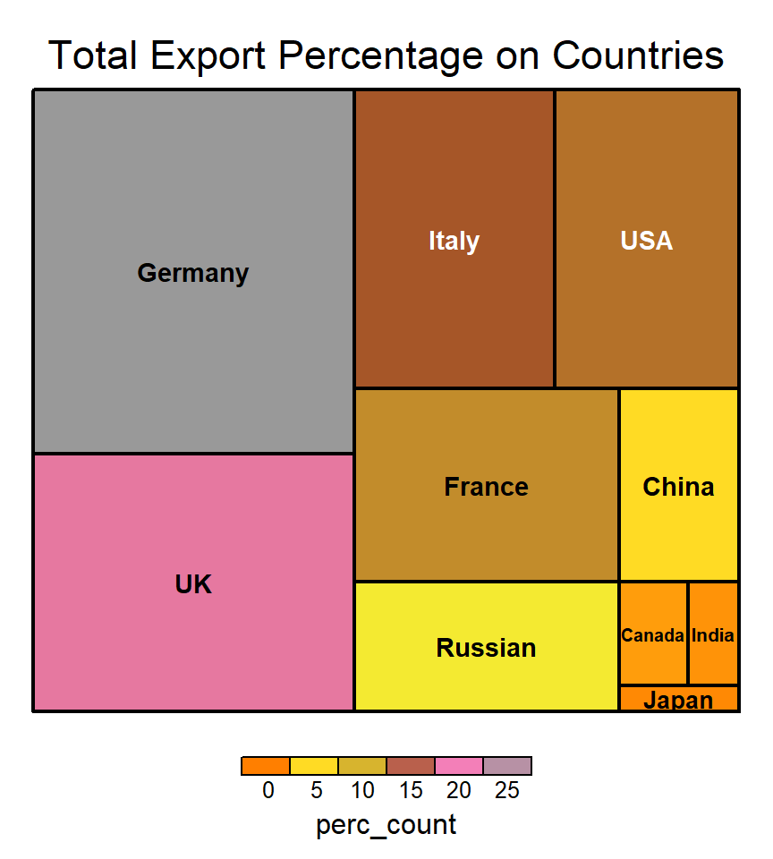

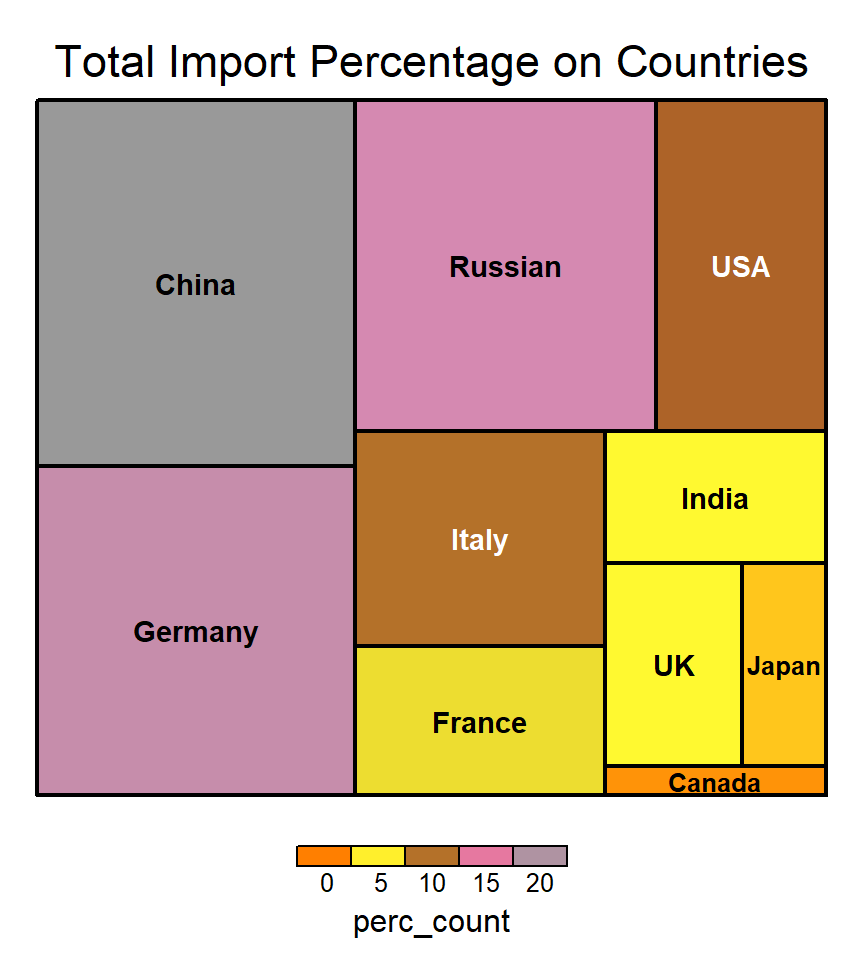

## Analysis

### Breakdown of Total Export & Import

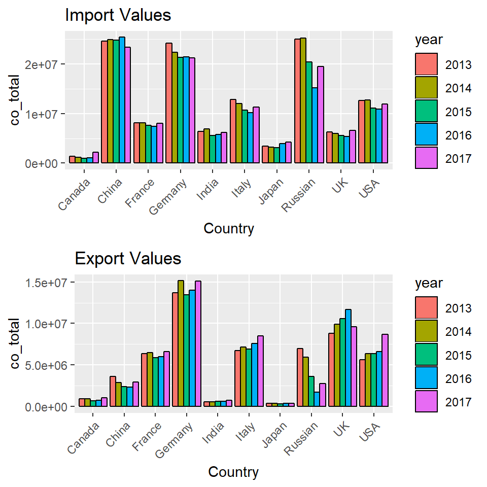

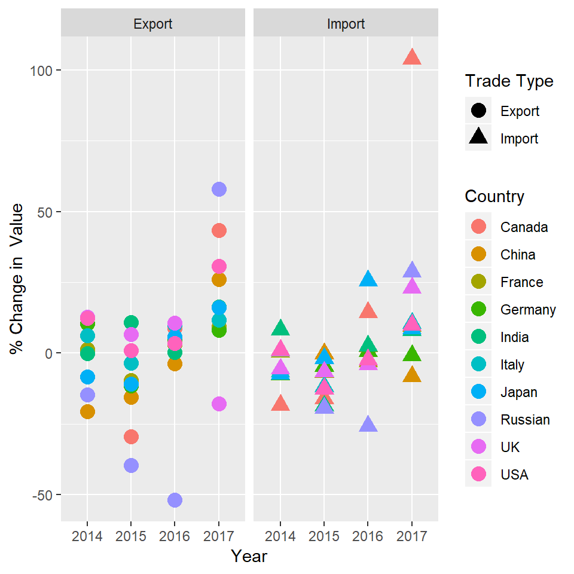

## Analysis

### Year over Year Changes in Trade Values - Export & Import - Canada

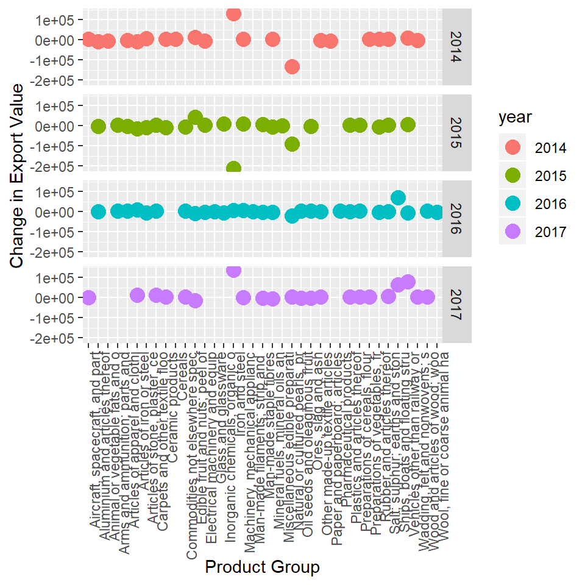

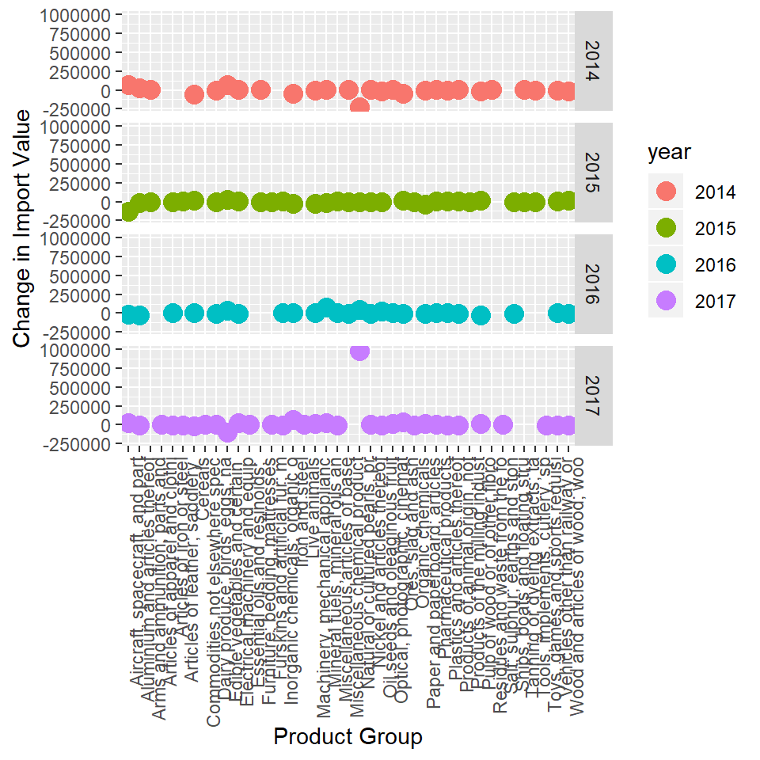

## Analysis

### Year over Year Changes in Trade Values - Exports & Imports to Russia

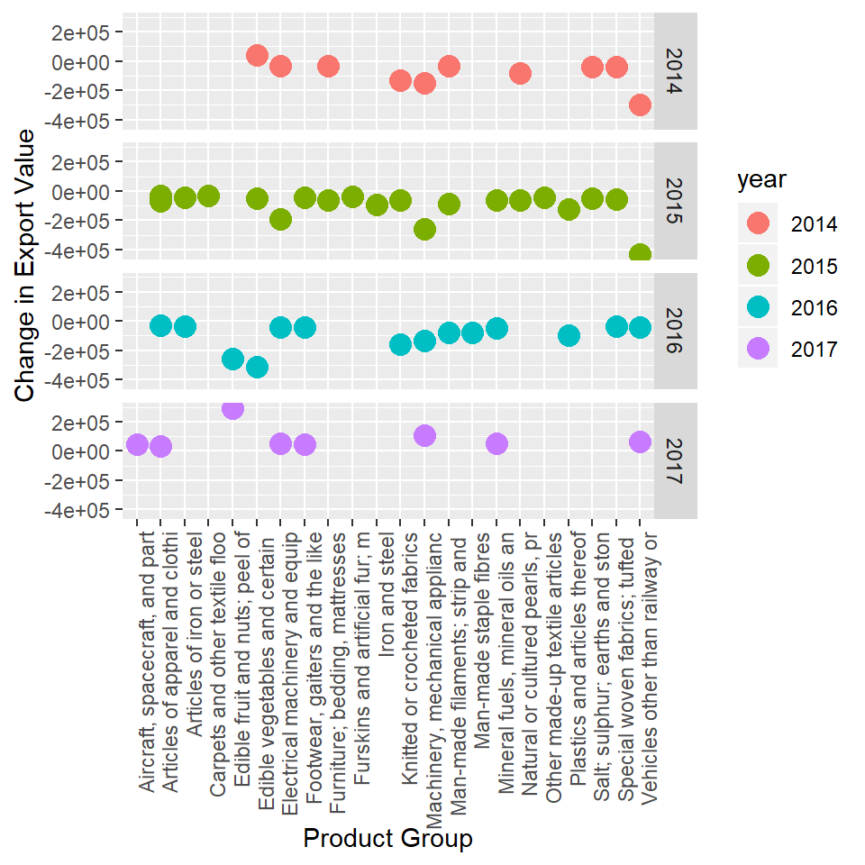

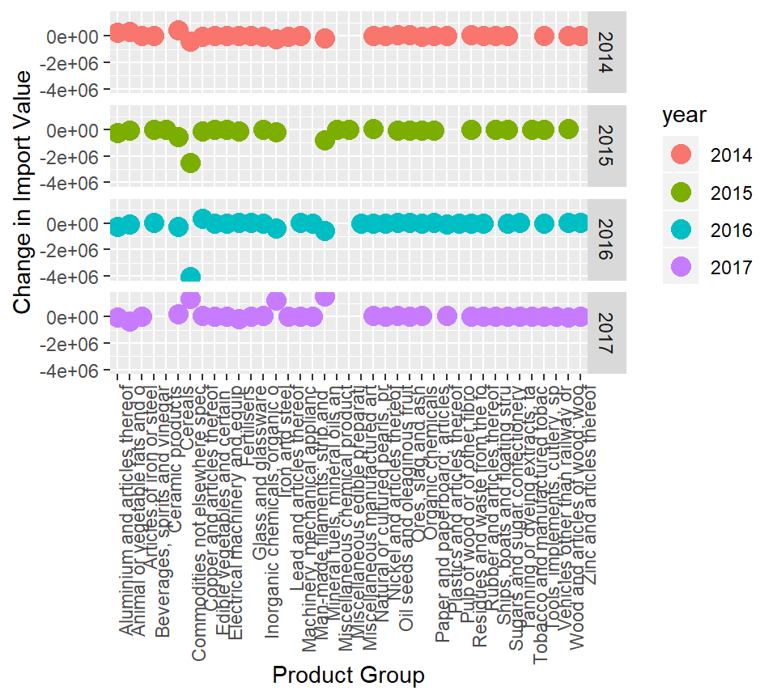

Discover more with *[Shiny](https://groupfour.shinyapps.io/tradeOrg)*

## Analysis

### Trade Deficit and Effects of Countries on Trade Deficit

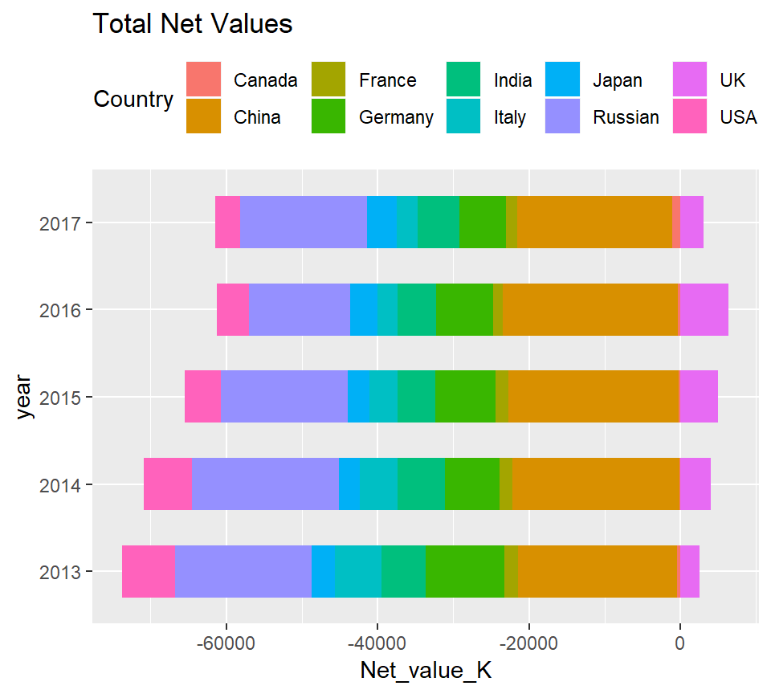

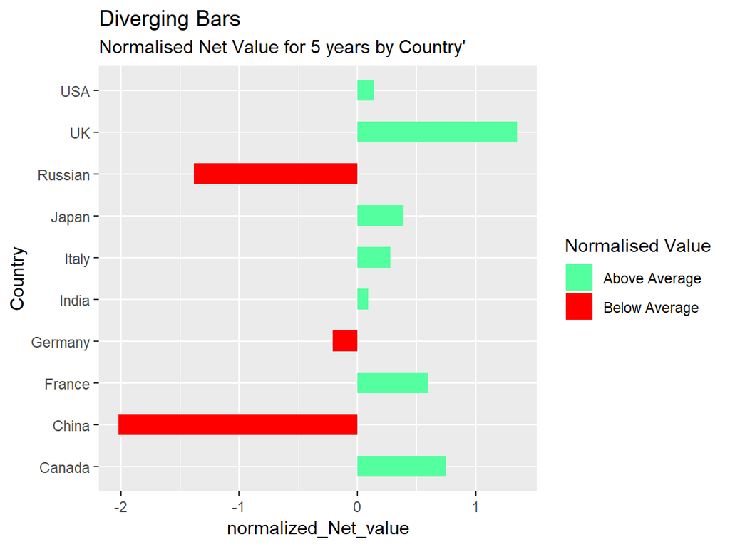

Discover more with *[Shiny](https://groupfour.shinyapps.io/tradeOrgProAnly/)*

## Analysis

### Analysis of the Import Unit Prices and Export Unit Prices

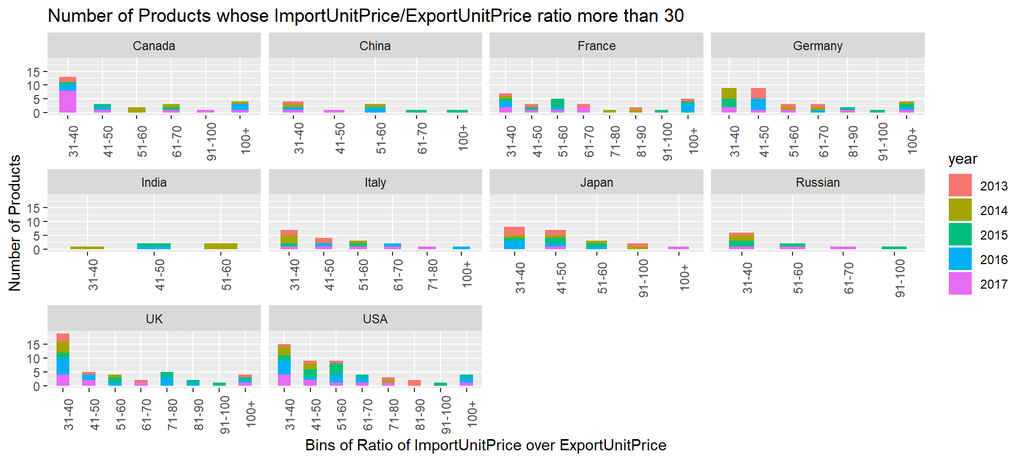

Discover more with *[Shiny](https://groupfour.shinyapps.io/tradeOrgProUnitP/)*